# Avance I Proyecto Final del Curso DAT-004

Jose Francisco Nuñez Obando

06/12/2019

# 1 Introducción

El siguiente documento corresponde al primer avance del trabajo de investigación del curso Visualización de datos y análisis estadístico del Posgrado Analista de Datos de la Universidad Cenfotec.

A continuación, se exponen el tema a tratar en esta investigación, los objetivos planteados, asi como una muestra del dataset que se empleara en dicha investigación.

# 2 Tema de investigación

“Estadisticas y Modelado de la distribución biogeográfica de Pumas y Jaguares de un sector del continente americano”

# 3 Fuentes de datos

www.inaturalist.org/  
https://biodiversityinformatics.amnh.org/

# 4 Objetivos

- 1. Estadísticas espacio-temporales sobre los pumas y jaguares de un sector del continente americano, en las que se evalua: frecuencia de observaciones, patrones de distribución, densidad por pais y por zonas, cercanías con centros poblados
- 2. Analisis de interpolación de Krigging respecto del número de individuos observados por año
- 3. Modelado de la distribución de los pumas y jaguares del área de estudio, según la máxima entropía con la cual se determina la probabilidad de condiciones adecuadas para la especie

# 5 Librerias

```r
library(dplyr)
library(sp)
library(DT)
library(leaflet)
library(raster)
library(ggplot2)
library(here)
library(rasterVis)
```

# 6 Procesos de extracción, transformación y carga de las Bases de datos

En esta sección se realizan una serie de procesos que conllevan al desarrollo de las bases de datos finales.

## 6.1 1. Base de datos sobre felinos

```r
df <- read.csv("E:/Analista de datos/DAT004/Proyecto Final/Datasets/samples/wildcats_df.csv", stringsAsFactors=F, sep=",", encoding="UTF-8")

colnames(df)
```

```
## [1] "X.U.FEFF.common_name" "scientific_name"      "latitude"
## [4] "longitude"            "created_at"           "updated_at"
## [7] "place_country_name"
```

### 6.1.1 Cambio de nombre de las columnas

```r
names(df)[1] <- "Nombre_Comun"
names(df)[2] <- "Nombre_Cientifico"
names(df)[3] <- "Latitud"
names(df)[4] <- "Longitud"
names(df)[5] <- "Fecha_Creacion"
names(df)[6] <- "Fecha_Actualizacion"
names(df)[7] <- "Pais"

colnames(df)
```

```
## [1] "Nombre_Comun"        "Nombre_Cientifico"   "Latitud"
## [4] "Longitud"            "Fecha_Creacion"      "Fecha_Actualizacion"
## [7] "Pais"
```

### 6.1.2 Resumen de datos por especie

#### 6.1.2.1 Conteo inicial

```r
df%>%
  group_by(Nombre_Comun)%>%
  summarise(length(Nombre_Comun))
```

| Nombre_Comun | length(Nombre_Comun) |
| --- | --- |
| Jaguar | 1435 |
| Puma | 2178 |
| Puma de América del Norte | 258 |
| Puma de América del Sur | 56 |

#### 6.1.2.2 Correccion de datos en la columna de “Nombre_Comun”

```r
ndf <- df%>%
  mutate(Nombre_Comun=ifelse(Nombre_Comun=="Puma de América del Norte", "Puma",Nombre_Comun))%>%
  mutate(Nombre_Comun=ifelse(Nombre_Comun=="Puma de América del Sur", "Puma",Nombre_Comun))
```

#### 6.1.2.3 Resumen final de datos por especie

```r
ndf%>%
  group_by(Nombre_Comun)%>%
  summarise(length(Nombre_Comun))
```

| Nombre_Comun | length(Nombre_Comun) |
| --- | --- |
| Jaguar | 1435 |
| Puma | 2492 |

### 6.1.3 Mapa de la distribicion de las especies a nivel mundial

```r
cf <- colorFactor(c("#ffa500", "#13ED3F"), domain=ndf$Nombre_Comun)
m <- leaflet(df) %>% addTiles(group = "OSM (default)") %>%
  addProviderTiles(providers$Stamen.Toner, group = "Toner") %>%
  addProviderTiles(providers$Stamen.TonerLite, group = "Toner Lite") %>%
  setView(-63.54105072, -8.88123188, zoom = 2) %>%
  addCircles(~Longitud, ~Latitud, popup=ndf$Nombre_Comun, group = ndf$Nombre_Comun ,weight = 3, radius=4,
              color=cf(ndf$Nombre_Comun), stroke = TRUE, fillOpacity = 0.5)  %>%
  addLegend("bottomright", colors= c("#ffa500", "#13ED3F"), labels=c("Puma", "Jaguar"), title="Especies") %>%
  addLayersControl(
    baseGroups = c("OSM (default)", "Toner", "Toner Lite"),
    overlayGroups = ndf$Nombre_Comun,
    options = layersControlOptions(collapsed = TRUE)
  )

m
```

[interactive chart not shown]

## 6.2 2. Bases de datos sobre variables ambientales del área de estudio

El area de estudio con la que se pretende trabajar corresponde a Centro y Sudamrica, asi como el Caribe.

Algunas de las coberturas que se utilizan para conocer el habitat de las especies son:

```r
r_files <- list.files(here::here("Datasets", "coverages"),
                       full.names = T)
r_files
```

```
##  [1] "E:/Analista de datos/DAT004/Proyecto Final/Datasets/coverages/cld6190_ann.asc"
##  [2] "E:/Analista de datos/DAT004/Proyecto Final/Datasets/coverages/dtr6190_ann.asc"
##  [3] "E:/Analista de datos/DAT004/Proyecto Final/Datasets/coverages/ecoreg.asc"
##  [4] "E:/Analista de datos/DAT004/Proyecto Final/Datasets/coverages/frs6190_ann.asc"
##  [5] "E:/Analista de datos/DAT004/Proyecto Final/Datasets/coverages/h_dem.asc"
##  [6] "E:/Analista de datos/DAT004/Proyecto Final/Datasets/coverages/pre6190_ann.asc"
##  [7] "E:/Analista de datos/DAT004/Proyecto Final/Datasets/coverages/pre6190_l1.asc"
##  [8] "E:/Analista de datos/DAT004/Proyecto Final/Datasets/coverages/pre6190_l10.asc"
##  [9] "E:/Analista de datos/DAT004/Proyecto Final/Datasets/coverages/pre6190_l4.asc"
## [10] "E:/Analista de datos/DAT004/Proyecto Final/Datasets/coverages/pre6190_l7.asc"
## [11] "E:/Analista de datos/DAT004/Proyecto Final/Datasets/coverages/tmn6190_ann.asc"
## [12] "E:/Analista de datos/DAT004/Proyecto Final/Datasets/coverages/tmp6190_ann.asc"
## [13] "E:/Analista de datos/DAT004/Proyecto Final/Datasets/coverages/tmx6190_ann.asc"
## [14] "E:/Analista de datos/DAT004/Proyecto Final/Datasets/coverages/vap6190_ann.asc"
```

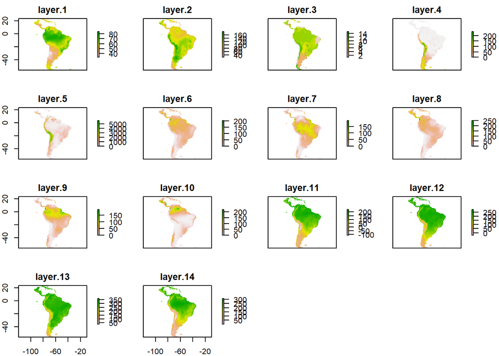

```r
st <- stack(r_files)

plot(st)
```

#### 6.2.0.1 Muestra de una de las variables ambientales: Ecoregiones

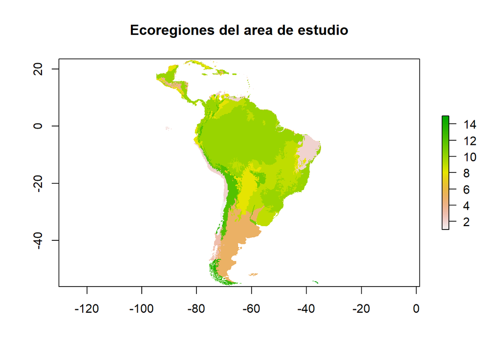

```r
ecoreg = raster(r_files[3])
plot(ecoreg, main="Ecoregiones del area de estudio")
```

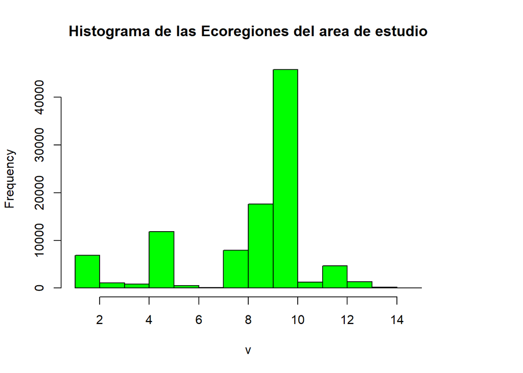

```r
hist(ecoreg, main="Histograma de las Ecoregiones del area de estudio", col="green")
```

## 6.3 3. Selección de la base de datos de las especies respecto del área de estudio

```r
coords <- data.frame(x=ndf$Longitud, y=ndf$Latitud)
prj <- CRS("+proj=longlat +datum=WGS84 +no_defs")
points <- SpatialPointsDataFrame(coords, ndf, proj4string = prj)
wildcats <- crop(points,ecoreg)
wildcats <- data.frame(wildcats)
wildcats <- wildcats[,1:7]
```

### 6.3.1 Mapeo de los ubicaciones registradas de las especies en el área de estudio

```r
cf2 <- colorFactor(c("#ffa500", "#13ED3F"), domain=wildcats$Nombre_Comun)
m2 <- leaflet(wildcats) %>% addTiles(group = "OSM (default)") %>%
  addProviderTiles(providers$Stamen.Toner, group = "Toner") %>%
  addProviderTiles(providers$Stamen.TonerLite, group = "Toner Lite") %>%
  setView(-63.54105072, -8.88123188, zoom = 2) %>%
  addCircles(~Longitud, ~Latitud, popup=wildcats$Nombre_Comun, group = wildcats$Nombre_Comun ,weight = 3, radius=4,
              color=cf2(wildcats$Nombre_Comun), stroke = TRUE, fillOpacity = 0.5)  %>%
  addLegend("bottomright", colors= c("#ffa500", "#13ED3F"), labels=c("Puma", "Jaguar"), title="Especies") %>%
  addLayersControl(
    baseGroups = c("OSM (default)", "Toner", "Toner Lite"),
    overlayGroups = wildcats$Nombre_Comun,
    options = layersControlOptions(collapsed = TRUE)
  )

m2
```

[interactive chart not shown]

### 6.3.2 Selección final de la base de datos

```r
datatable(wildcats, filter = 'top', options = list(
  pageLength = 5, autoWidth = TRUE
))
```

|  | Nombre_Comun | Nombre_Cientifico | Latitud | Longitud | Fecha_Creacion | Fecha_Actualizacion | Pais |
| --- | --- | --- | --- | --- | --- | --- | --- |
| 1 | Jaguar | Panthera onca | -17.293397202 | -56.7733499016 | 2011-10-05 23:04:07 UTC | 2018-06-30 15:36:20 UTC | Brazil |
| 2 | Jaguar | Panthera onca | 10.2041951816 | -83.488043602 | 2011-12-02 19:02:28 UTC | 2018-06-30 15:36:21 UTC | Costa Rica |
| 3 | Jaguar | Panthera onca | 18.9198830817 | -89.4563255483 | 2013-02-07 19:36:04 UTC | 2018-06-21 17:29:16 UTC | Mexico |
| 5 | Jaguar | Panthera onca | -18.1427728908 | -52.8430576581 | 2013-06-15 04:00:39 UTC | 2019-07-21 19:55:46 UTC | Brazil |
| 7 | Jaguar | Panthera onca | 16.544653429 | -88.6183141282 | 2013-07-10 17:38:55 UTC | 2014-07-01 11:56:32 UTC | Belize |
| 9 | Jaguar | Panthera onca | 18.7942606404 | -89.4379153175 | 2013-08-14 13:07:43 UTC | 2017-07-07 20:17:52 UTC | Mexico |
| 10 | Jaguar | Panthera onca | 10.461740748 | -83.4776469392 | 2013-09-13 14:24:40 UTC | 2014-07-01 12:53:59 UTC | Costa Rica |
| 12 | Jaguar | Panthera onca | 18.5783934131 | -88.2555087055 | 2013-10-26 02:53:17 UTC | 2018-06-30 15:47:57 UTC | Mexico |
| 14 | Jaguar | Panthera onca | -17.2514496989 | -56.6663992181 | 2014-01-10 15:45:53 UTC | 2019-02-13 19:08:59 UTC | Brazil |
| 15 | Jaguar | Panthera onca | 16.0632573242 | -90.9954702957 | 2014-01-27 15:57:24 UTC | 2017-09-24 18:03:54 UTC | Mexico |

[output cut: 1022 more lines]